# MA0501 – Tarea 6

Autores/as

Diego Alberto Vega Víquez - C38367

José Carlos Quintero Cedeño - C26152

Gabriel Valverde Guzmán - C38060

Fecha de publicación

9 de noviembre de 2025

# Ejercicio 1

**Instrucción del ejercicio 1**

Implemente en **R** funciones para todos los algoritmos numéricos de resolución de ecuaciones diferenciales vistos en clase.

**Solución**

*Metodo de Euler*

**Código**

```r
metodo.euler <- function(a, b, N, alfa, f){
  h <- (b - a) / N
  t <- a
  w <- alfa
  T <- numeric(N + 1)
  W <- numeric(N + 1)
  T[1] <- t
  W[1] <- w
  for (i in 2:(N+1)) {
    W[i] <- W[i-1] + h*f(T[i-1],W[i-1])
    T[i] <- t + (i - 1)*h
  }

  tabla <- data.frame(t = T, w = W)

  return(list(t = T, w = W, tabla = tabla))
}
```

**Metodo de Euler predictor-corrector**

**Código**

```r
metodo.euler.predictor.corrector <- function(a, b, N, alfa, f){
  h <- (b - a) / N
  t <- a
  w <- alfa
  T <- numeric(N + 1)
  W <- numeric(N + 1)
  T[1] <- t
  W[1] <- w
  for (i in 2:(N+1)) {
    W[i] <- W[i-1] + h*f(T[i-1],W[i-1]) #predictor
    T[i] <- T[i - 1] + h
    W[i] <- W[i-1] + (h/2)*(f(T[i-1], W[i-1]) + f(T[i], W[i])) #corrector
  }

  tabla <- data.frame(t = T, w = W)

  return(list(t = T, w = W, tabla = tabla))
}
```

**Metodo de Runge-Kutta de punto medio**

**Código**

```r
runge.kutta.punto.medio <- function(a, b, N, alfa, f){
  h <- (b - a) / N
  t <- a
  w <- alfa
  T <- numeric(N + 1)
  W <- numeric(N + 1)
  T[1] <- t
  W[1] <- w
  for (i in 2:(N+1)) {
    W[i] <- W[i-1] + h*f(T[i-1] + (h/2),W[i-1] + (h/2)*f(T[i-1], W[i-1])) #predictor
    T[i] <- T[i - 1] + h
  }

  tabla <- data.frame(t = T, w = W)

  return(list(t = T, w = W, tabla = tabla))
}
```

**Mertodo de Runge-Kutta de cuarto orden**

**Código**

```r
runge.kutta.cuarto.orden <- function(a, b, N, alfa, f){
  h <- (b - a) / N
  t <- a
  w <- alfa
  T <- numeric(N + 1)
  W <- numeric(N + 1)
  T[1] <- t
  W[1] <- w
  for (i in 2:(N+1)) {
    k1 <- h*f(T[i-1], W[i-1])
    k2 <- h*f(T[i-1] + h/2, W[i-1] + k1/2)
    k3 <- h*f(T[i-1] + h/2, W[i-1] + k2/2)
    k4 <- h*f(T[i-1] + h, W[i-1] + k3)

    W[i] <- W[i-1] + (1/6)*(k1 + 2*k2 + 2*k3 + k4)
    T[i] <- T[i - 1] + h
  }

  tabla <- data.frame(t = T, w = W)

  return(list(t = T, w = W, tabla = tabla))
}
```

# Ejercicio 2

**Instrucción del ejercicio 2**

Complete los detalles de las demostraciones que quedaron pendientes en este capítulo.

**Solución**

**Lema 3**

Sea $(\xi_j)$ una sucesión en $\mathbb{R}$ con la propiedad

$$|\xi_{j+1}| \le (1+A)\,|\xi_j| + B, \qquad j=0,1,2,\ldots,$$

para algunas constantes $A>0$ y $B\ge 0$. Entonces, para todo $j\ge 0$ se cumple

$$|\xi_j| \le |\xi_0|\,e^{jA} + \frac{B}{A}\big(e^{jA}-1\big).$$

**Prueba**

Sea $a_j := |\xi_j| \ge 0$. La hipótesis dice
$$a_{j+1} \le (1+A)\,a_j + B, \qquad j\ge 0.$$

**Paso 1 (desenrollando la recurrencia).**
Probamos por inducción que para todo $j\ge 0$,
$$a_j \le (1+A)^j a_0 + B\sum_{k=0}^{j-1}(1+A)^k. \tag{1}$$

- Para $j=0$, la afirmación es trivial: $a_0 \le (1+A)^0 a_0 + 0$.
- Suponga que vale para $j$. Entonces, usando la recurrencia,
  $$\begin{aligned}
  a_{j+1}
  &\le (1+A)\,a_j + B \\
  &\le (1+A)\Big[(1+A)^j a_0 + B\sum_{k=0}^{j-1}(1+A)^k\Big] + B \\
  &= (1+A)^{j+1} a_0 + B\sum_{k=1}^{j}(1+A)^k + B \\
  &= (1+A)^{j+1} a_0 + B\sum_{k=0}^{j}(1+A)^k,
  \end{aligned}$$
  que es la fórmula (1) con $j$ reemplazado por $j+1$. Queda probado por inducción.

De (1) y la suma geométrica,
$$\sum_{k=0}^{j-1}(1+A)^k=\frac{(1+A)^j-1}{A},$$
obtenemos
$$a_j \le (1+A)^j a_0 + \frac{B}{A}\big((1+A)^j-1\big). \tag{2}$$

**Paso 2 (paso de $(1+A)^j$ a $e^{Aj}$).**
Usando que $(1+A)^j \le e^{Aj}$ para $A>0$ (por $1+x\le e^x$), en (2) se concluye
$$a_j \le a_0\,e^{Aj} + \frac{B}{A}\big(e^{Aj}-1\big).$$

Recordando que $a_j=|\xi_j|$ y $a_0=|\xi_0|$, queda
$$|\xi_j| \le |\xi_0|\,e^{jA} + \frac{B}{A}\big(e^{jA}-1\big), \qquad j=0,1,2,\ldots$$
como se quería. $\blacksquare$

**Teorema 6**

Si la función $\varphi$ en un método de un paso es continua (con respecto a $h$) y satisface la **condición de Lipschitz**

$$|\varphi(x,u;h) - \varphi(x,v;h)| \le M\,|u - v|,$$

para todo $(x,u),(x,v)\in G$ y para $h$ suficientemente pequeño,  
entonces **un método de un paso es convergente si y solo si el método es consistente.**

**Prueba**

**1. (Consistencia $\Rightarrow$ Convergencia)**

Sea $e_j = u_j - u(x_j)$ el error global en el nodo $x_j$.  
Se tiene que:

$$\begin{aligned}
e_{j+1} - e_j
&= [u_{j+1} - u_j] - [u(x_{j+1}) - u(x_j)] \\
&= h\,\varphi(x_j,u_j;h) - [u(x_{j+1}) - u(x_j)] \\
&= h\,[\,\varphi(x_j,u_j;h) - \varphi(x_j,u(x_j);h) - \Delta(x_j,u(x_j);h)\,].
\end{aligned}$$

Por la condición de Lipschitz, se obtiene:

$$|e_{j+1} - e_j| \le h\,[\,M\,|u_j - u(x_j)| + c(h)\,], \tag{1.14}$$

donde
$$c(h) := \max_{a \le x \le b} |\Delta(x,u(x);h)|.$$

Nótese que $c(h)\to 0$ cuando $h\to 0$, pues el método es consistente.

**2. (Aplicación del Lema 3)**

Como $e_j = u_j - u(x_j)$, la desigualdad (1.14) implica que:

$$|e_{j+1}| \le (1 + hM)\,|e_j| + h\,c(h), \qquad j = 0,1,2,\ldots,n.$$

Aplicando el **Lema 3** con $A = hM$, $B = h\,c(h)$ y observando que $e_0 = 0$, se deduce:

$$|e_j| \le \frac{h\,c(h)}{hM}\,\big(e^{j hM} - 1\big), \qquad j=0,1,2,\ldots,n.$$

Como $x_j = x_0 + jh$, esto se puede reescribir como:

$$|e_j| \le \frac{c(h)}{M}\,\big(e^{M(x_j - x_0)} - 1\big), \qquad j=0,1,2,\ldots,n. \tag{1.15}$$

Por tanto, el **error global máximo** cumple:

$$E(h) = \max_j |e_j|
\le \frac{c(h)}{M}\,\big(e^{M(b-a)} - 1\big)
\longrightarrow 0 \quad \text{cuando } h\to 0.$$

Esto prueba que el método es **convergente**.

**3. (Convergencia $\Rightarrow$ Consistencia)**

Recordemos (Def. 7) que el **error de discretización local** en un punto $(x,u)$ se define por
$$\Delta(x,u;h)=\frac{\eta(x+h)-\eta(x)}{h}-\varphi(x,u;h),$$
donde $\eta$ es la solución del problema auxiliar $\eta' = f(\xi,\eta)$ con condición inicial $\eta(x)=u$. Además, por el Teorema 3, un método de un paso es **consistente** si y sólo si
$$\lim_{h\to0}\varphi(x,u;h)=f(x,u)
\qquad(\text{uniformemente en }(x,u)\in G).$$

Sea ahora un método de un paso **convergente** en el sentido de la Def. 10. Fijemos $(x,u)\in G$ y apliquemos el método sobre el intervalo corto $[x,x+h]$ partiendo exactamente de $u(x)=u$. Denotemos por
$$U_1 := u + h\,\varphi(x,u;h)$$
la aproximación numérica al valor exacto $\eta(x+h)$ tras un solo paso. El error en ese único nodo es
$$e_1 \;=\; U_1-\eta(x+h)
\;=\; h\Big(\varphi(x,u;h)-\frac{\eta(x+h)-\eta(x)}{h}\Big)
\;=\; -\,h\,\Delta(x,u;h). \tag{1}$$

Como el método es convergente, aplicado al problema en $[x,x+h]$ (se trata de un problema del mismo tipo pero en un intervalo de longitud $h$), se tiene que el error global máximo en ese intervalo, que aquí coincide con $|e_1|$, satisface
$$|e_1| \longrightarrow 0 \qquad \text{cuando } h\to0 .$$

Dividiendo (1) entre $h$ obtenemos
$$|\Delta(x,u;h)| \;=\; \frac{|e_1|}{h}.$$

Usando que $\varphi$ es Lipschitz en la segunda variable y continua en $h$ y que $f$ es localmente acotada, el error tras un paso satisface la cota estándar (obtenida con Grönwall)
$$|e_1| \;\le\; C\,h \qquad \text{para $h$ suficientemente pequeño,}$$
con $C$ independiente de $h$ y de $(x,u)$ en compactos de $G$. Por lo tanto
$$|\Delta(x,u;h)|
\;=\; \frac{|e_1|}{h}
\;\le\; C \qquad\text{y, además,}\qquad
\lim_{h\to0} |\Delta(x,u;h)|=\lim_{h\to0}\frac{|e_1|}{h}=0,$$
ya que $|e_1|=o(h)$ cuando $h\to0$ (convergencia en un paso).

Con ello se concluye que
$$\lim_{h\to0}\Delta(x,u;h)=0
\quad\Longleftrightarrow\quad
\lim_{h\to0}\varphi(x,u;h)=\lim_{h\to0}\frac{\eta(x+h)-\eta(x)}{h}
= \eta'(x)=f(x,u),$$
uniformemente en $(x,u)\in G$. Es decir, el método es **consistente**.

$\blacksquare$

**Corolario 2**

1. El **método de Euler** es convergente y, si $f$ es continuamente diferenciable, entonces el **orden de convergencia** es $1$.
2. El **método de Euler modificado** (o de Heun) es convergente y, si $f$ es dos veces continuamente diferenciable, entonces el **orden de convergencia** es $2$.

**Prueba**

**Para 1. (Euler clásico).**
El método de Euler tiene
$$\varphi(x,u;h)=f(x,u).$$

- **Lipschitz en $u$:** Si $f$ es Lipschitz en su segunda variable con constante $L$ (uniforme en $x$), entonces
  $$|\varphi(x,u;h)-\varphi(x,v;h)|=|f(x,u)-f(x,v)|\le L\,|u-v|.$$
- **Consistencia y orden:** Por el **Teorema 4** (ya demostrado), Euler es consistente y, si $f$ es $C^1$, su **orden de consistencia es $1$**.

Aplicando el **Teorema 6** (consistencia $\Longleftrightarrow$ convergencia bajo Lipschitz) y el **Teorema 7** (el orden de convergencia coincide con el orden de consistencia), se concluye que Euler **converge con orden $1$**.

**Para 2. (Euler modificado / Heun).**
En este caso
$$\varphi(x,u;h)=\frac12\Big[f(x,u)+f\!\big(x+h,\,u+h\,f(x,u)\big)\Big].$$

- **Lipschitz en $u$:** Suponga que $f$ es Lipschitz en su segunda variable con constante $L$ (uniforme en $x$). Entonces, para $u,v$ cualesquiera,

$$\begin{align*}
|\varphi(x,u;h)-\varphi(x,v;h)|
&\le \tfrac12\,|f(x,u)-f(x,v)|
+\tfrac12\,\Big|f\!\big(x+h,\,u+h f(x,u)\big)-f\!\big(x+h,\,v+h f(x,v)\big)\Big| \\
&\le \tfrac12\,L|u-v|
+\tfrac12\,L\,\big|[u-v]+h\,[f(x,u)-f(x,v)]\big| \\
&\le \tfrac12\,L|u-v|
+\tfrac12\,L\,(|u-v|+h\,L|u-v|) \\
&= L\Big(1+\tfrac12\,hL\Big)\,|u-v|.
\end{align*}$$

Así, $\varphi$ es Lipschitz en $u$ con constante $M=L(1+\tfrac12 hL)$ (válida para $h$ pequeño).

- **Consistencia y orden:** Por el resultado demostrado para Euler mejorado, si $f\in C^2$ entonces el método es **consistente de orden $2$**.

Aplicando de nuevo el **Teorema 6** (bajo Lipschitz hay equivalencia entre consistencia y convergencia) y el **Teorema 7** (el orden de convergencia coincide con el de consistencia), se concluye que el método de Euler modificado **converge con orden $2$**.

$\blacksquare$

**Definición 11**

El método de **Runge–Kutta de cuarto orden (RK4)** para resolver el problema de valor inicial:

$$\begin{cases}
u' = f(x, u), \\
u(x_0) = u_0,
\end{cases}$$

construye una aproximación $u_j$ de $u(x_j)$ en la malla de puntos equidistantes  
$x_j := x_0 + jh$ para $j = 1, 2, \ldots$, usando las siguientes ecuaciones:

$$\begin{align*}
k_1 &= f(x_j, u_j), \\
k_2 &= f\!\left(x_j + \frac{h}{2},\, u_j + \frac{h}{2}k_1\right), \\
k_3 &= f\!\left(x_j + \frac{h}{2},\, u_j + \frac{h}{2}k_2\right), \\
k_4 &= f(x_j + h,\, u_j + h k_3), \\
u_{j+1} &= u_j + \frac{h}{6}\,(k_1 + 2k_2 + 2k_3 + k_4).
\end{align*}$$

**Observaciones**

1. El método fue introducido por **Runge** en 1895 y extendido por **Kutta** en 1901 para sistemas de ecuaciones diferenciales.
2. Si $u' = f(x)$, el método de Runge–Kutta y la **regla de Simpson** son equivalentes (pruébelo).

**Prueba**

Sea $u' = f(x)$, es decir, $u(x)$ es una primitiva de $f(x)$. Entonces, la solución exacta cumple:
$$u(x_{j+1}) = u(x_j) + \int_{x_j}^{x_{j+1}} f(x) \, dx.$$

El método de Runge–Kutta de orden 4 estima $u_{j+1}$ mediante:
$$\begin{align*}
k_1 &= f(x_j), \\
k_2 &= f\left(x_j + \frac{h}{2} \right), \\
k_3 &= f\left(x_j + \frac{h}{2} \right), \\
k_4 &= f(x_j + h), \\
u_{j+1} &= u_j + \frac{h}{6}(k_1 + 2k_2 + 2k_3 + k_4).
\end{align*}$$

Observamos que como $u' = f(x)$, la evaluación de $f$ no depende de $u_j$, por lo tanto:
$$k_2 = k_3 = f\left(x_j + \frac{h}{2} \right).$$

Sustituyendo:
$$\begin{align*}
u_{j+1} &= u_j + \frac{h}{6} \left[ f(x_j) + 2f\left(x_j + \frac{h}{2} \right) + 2f\left(x_j + \frac{h}{2} \right) + f(x_j + h) \right] \\
&= u_j + \frac{h}{6} \left[ f(x_j) + 4f\left(x_j + \frac{h}{2} \right) + f(x_j + h) \right].
\end{align*}$$

Esto coincide exactamente con la **regla de Simpson** para la integral de $f$ en el intervalo $[x_j, x_{j+1}]$, que aproxima:
$$\int_{x_j}^{x_{j+1}} f(x)\,dx \approx \frac{h}{6}\left[f(x_j) + 4f\left(x_j + \frac{h}{2}\right) + f(x_j + h)\right].$$

Luego:
$$u_{j+1} = u_j + \int_{x_j}^{x_{j+1}} f(x)\,dx \approx u_j + \text{(Simpson)} = \text{RK4}.$$

3. Resumiendo, el método de **Runge–Kutta** se puede escribir como:

$$\begin{cases}
w_0 = \alpha, \\
w_{i+1} = w_i + \dfrac{1}{6}\,(k_1 + 2k_2 + 2k_3 + k_4),
\end{cases}$$

donde:

$$\begin{align*}
k_1 &= h f(t_i, w_i), \\[0.5em]
k_2 &= h f\!\left(t_i + \frac{h}{2},\, w_i + \frac{k_1}{2}\right), \\[0.5em]
k_3 &= h f\!\left(t_i + \frac{h}{2},\, w_i + \frac{k_2}{2}\right), \\[0.5em]
k_4 &= h f(t_i + h,\, w_i + k_3).
\end{align*}$$

# Ejercicio 3

**Instrucción del ejercicio 3**

Para los problemas de valor inicial:

$$y' = -2ty^2, \quad y(0) = 1, \quad 0 \le t \le 1.$$

$$y' - y = \cos(t), \quad y(0) = \tfrac{1}{2}, \quad 0 \le t \le 1.$$

$$x\sqrt{1 - y^2}\,dx + y\sqrt{1 - x^2}\,dy = 0, \quad y(0) = 1, \quad 0 \le x \le 1.$$

1. Genere una tabla con cada uno de los métodos del ejercicio anterior con $N = 10$.
2. Encuentre la solución exacta usando **R**.
3. Mediante alguno de los métodos de interpolación vistos en el curso, interpole cada una de las soluciones obtenidas. Luego grafique en un mismo plano la solución exacta y el polinomio obtenido.
4. ¿Cuál de los métodos permitió obtener una mejor solución aproximada?

**Solución**

```r
library(deSolve)
```

1. Problema 1:

**Código**

```r
p1.euler <- metodo.euler(0, 1, 10, 1, function(t, y) -2*t*y^2)
p1.euler.pc <- metodo.euler.predictor.corrector(0, 1, 10, 1, function(t, y) -2*t*y^2)
p1.rkpm <- runge.kutta.punto.medio(0, 1, 10, 1, function(t, y) -2*t*y^2)
p1.rk4o <- runge.kutta.cuarto.orden(0, 1, 10, 1, function(t, y) -2*t*y^2)

data.frame(nodos = p1.euler$t, euler = p1.euler$w, euler.pred.corrector = p1.euler.pc$w, runge.kutta.punto.medio = p1.rkpm$w, runge.kutta.cuarto.orden = p1.rk4o$w)
```

```
   nodos     euler euler.pred.corrector runge.kutta.punto.medio
1    0.0 1.0000000            1.0000000               1.0000000
2    0.1 1.0000000            0.9900000               0.9900000
3    0.2 0.9800000            0.9613656               0.9611763
4    0.3 0.9415840            0.9172458               0.9167422
5    0.4 0.8883892            0.8619543               0.8611044
6    0.5 0.8252503            0.8000340               0.7988875
7    0.6 0.7571465            0.7355270               0.7341797
8    0.7 0.6883540            0.6715871               0.6701446
9    0.8 0.6220177            0.6103988               0.6089524
10   0.9 0.5601127            0.5532891               0.5519050
11   1.0 0.5036420            0.5009186               0.4996377
   runge.kutta.cuarto.orden
1                 1.0000000
2                 0.9900989
3                 0.9615381
4                 0.9174306
5                 0.8620682
6                 0.7999992
7                 0.7352935
8                 0.6711406
9                 0.6097561
10                0.5524865
11                0.5000006
```

Problema 2:

**Código**

```r
p2.euler <- metodo.euler(0, 1, 10, 1/2, function(x, y) cos(x) + y)
p2.euler.pc <- metodo.euler.predictor.corrector(0, 1, 10, 1/2, function(x, y) cos(x) + y)
p2.rkpm <- runge.kutta.punto.medio(0, 1, 10, 1/2, function(x, y) cos(x) + y)
p2.rk4o <- runge.kutta.cuarto.orden(0, 1, 10, 1/2, function(x, y) cos(x) + y)

data.frame(nodos = p2.euler$t, euler = p2.euler$w, euler.pred.corrector = p2.euler.pc$w, runge.kutta.punto.medio = p2.rkpm$w, runge.kutta.cuarto.orden = p2.rk4o$w)
```

```
   nodos     euler euler.pred.corrector runge.kutta.punto.medio
1    0.0 0.5000000            0.5000000               0.5000000
2    0.1 0.6500000            0.6572502               0.6573750
3    0.2 0.8145004            0.8299900               0.8302515
4    0.3 0.9939571            1.0188095               1.0192195
5    0.4 1.1888865            1.2243810               1.2249515
6    0.5 1.3998812            1.4474785               1.4482214
7    0.6 1.6276276            1.6889976               1.6899251
8    0.7 1.8729239            1.9499779               1.9511023
9    0.8 2.1367005            2.2316272               2.2329611
10   0.9 2.4200413            2.5353475               2.5369038
11   1.0 2.7242064            2.8627626               2.8645551
   runge.kutta.cuarto.orden
1                 0.5000000
2                 0.6575854
3                 0.8307038
4                 1.0199502
5                 1.2260027
6                 1.4496418
7                 1.6917710
8                 1.9534389
9                 2.2358637
10                2.5404593
11                2.8688634
```

Problema 3:

**Código**

```r
p3.euler <- metodo.euler(0, 1, 10, 1, function(t, y)- ( t * sqrt(1 - y^2) ) / ( y * sqrt(1 - t^2) ))
p3.euler.pc <- metodo.euler.predictor.corrector(0, 1, 10, 1, function(t, y)- ( t * sqrt(1 - y^2) ) / ( y * sqrt(1 - t^2) ))
p3.rkpm <- runge.kutta.punto.medio(0, 1, 10, 1, function(t, y)- ( t * sqrt(1 - y^2) ) / ( y * sqrt(1 - t^2) ))
p3.rk4o <- runge.kutta.cuarto.orden(0, 1, 10, 1, function(t, y)- ( t * sqrt(1 - y^2) ) / ( y * sqrt(1 - t^2) ))

data.frame(nodos = p3.euler$t, euler = p3.euler$w, euler.pred.corrector = p3.euler.pc$w, runge.kutta.punto.medio = p3.rkpm$w, runge.kutta.cuarto.orden = p3.rk4o$w)
```

```
   nodos euler euler.pred.corrector runge.kutta.punto.medio
1    0.0     1                    1                       1
2    0.1     1                    1                       1
3    0.2     1                    1                       1
4    0.3     1                    1                       1
5    0.4     1                    1                       1
6    0.5     1                    1                       1
7    0.6     1                    1                       1
8    0.7     1                    1                       1
9    0.8     1                    1                       1
10   0.9     1                    1                       1
11   1.0     1                    1                       1
   runge.kutta.cuarto.orden
1                         1
2                         1
3                         1
4                         1
5                         1
6                         1
7                         1
8                         1
9                         1
10                        1
11                        1
```

b y c) Problema 1:

**Código**

```r
edo <- function(t, y, parms) {
  dydt <- -2 * t * y^2
  list(dydt)
}

y0 <- 1
tiempos <- seq(0, 1, by = 0.1)

sol <- ode(y = y0, times = tiempos, func = edo, parms = NULL)
```

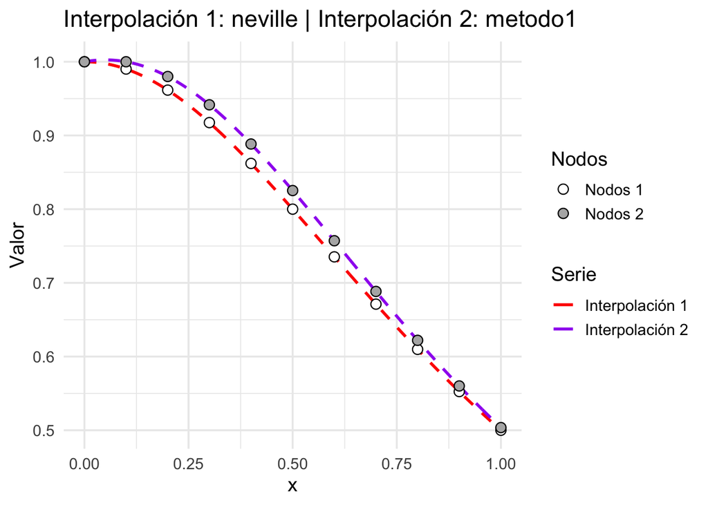

```r
graficar.polinomio(sol[,1], 0, 1, neville, valores1 = sol[,2], nodos2 =  p1.euler$t, valores2 = p1.euler$w)
```

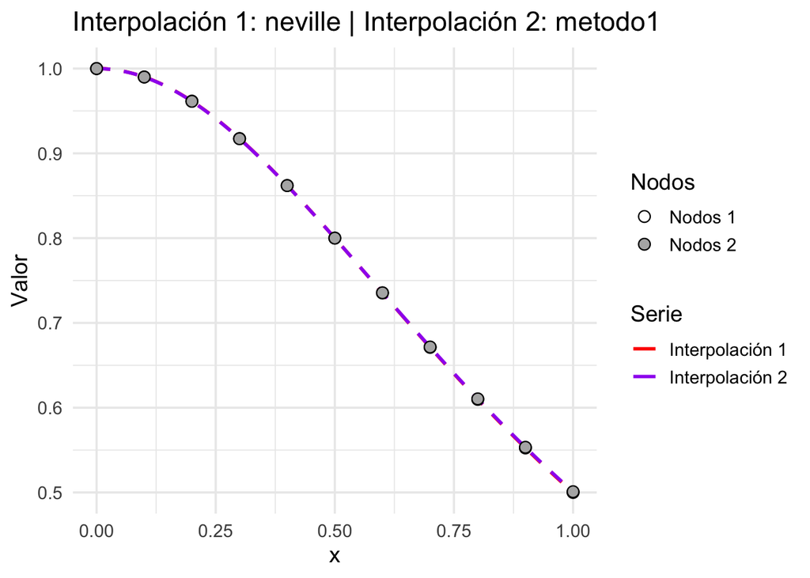

```r
graficar.polinomio(sol[,1], 0, 1, neville, valores1 = sol[,2], nodos2 =  p1.euler.pc$t, valores2 = p1.euler.pc$w)
```

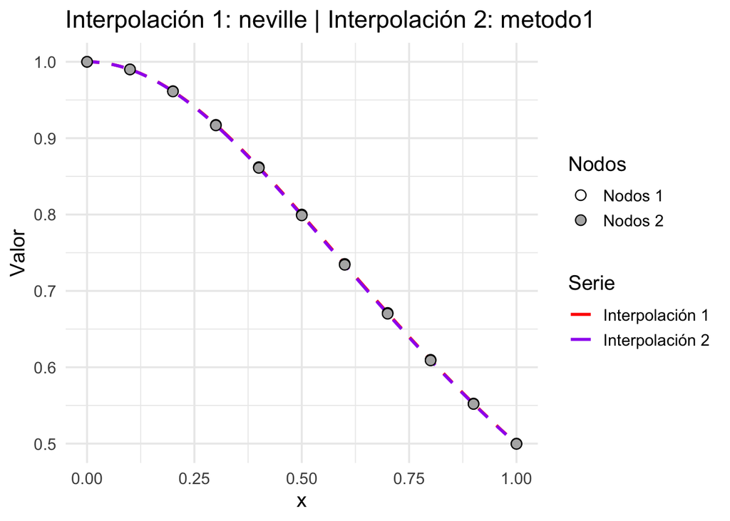

```r
graficar.polinomio(sol[,1], 0, 1, neville, valores1 = sol[,2], nodos2 =  p1.rkpm$t, valores2 = p1.rkpm$w)
```

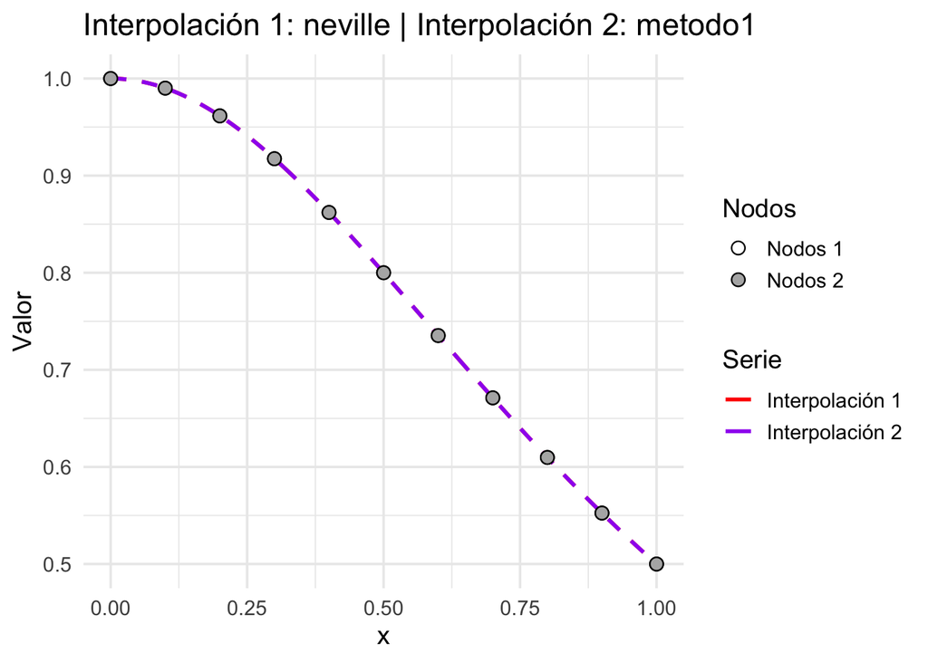

```r
graficar.polinomio(sol[,1], 0, 1, neville, valores1 = sol[,2], nodos2 =  p1.rk4o$t, valores2 = p1.rk4o$w)
```

Problema 2:

**Código**

```r
edo <- function(t, y, parms) {
  dydt <- cos(t) + y
  list(dydt)
}

y0 <- 1/2
tiempos <- seq(0, 1, by = 0.1)

sol <- ode(y = y0, times = tiempos, func = edo, parms = NULL)
```

**Código**

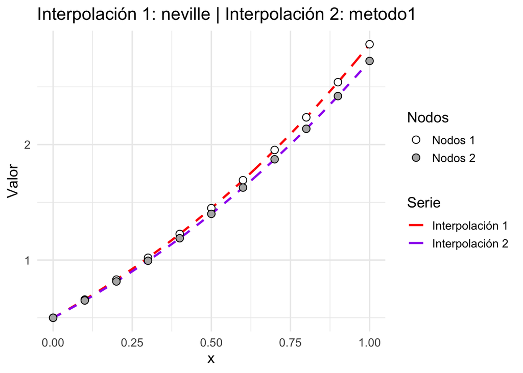

```r
graficar.polinomio(sol[,1], 0, 1, neville, valores1 = sol[,2], nodos2 =  p2.euler$t, valores2 = p2.euler$w)
```

**Código**

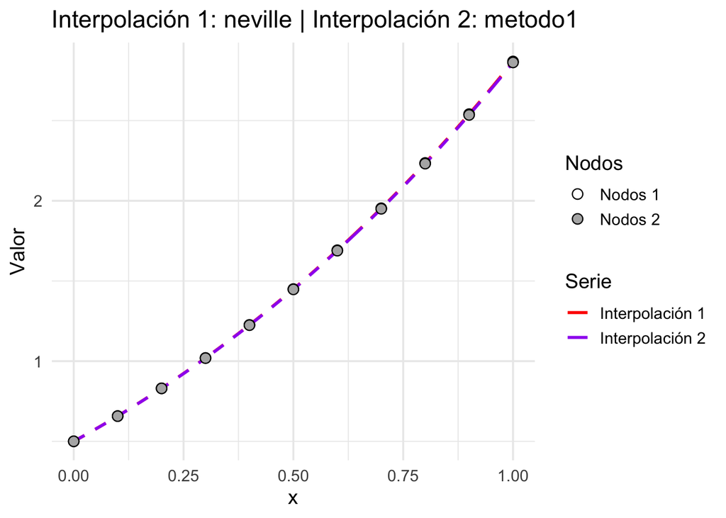

```r
graficar.polinomio(sol[,1], 0, 1, neville, valores1 = sol[,2], nodos2 =  p2.euler.pc$t, valores2 = p2.euler.pc$w)
```

**Código**

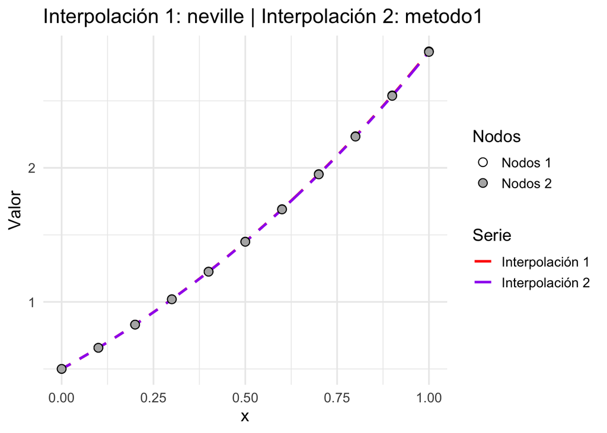

```r
graficar.polinomio(sol[,1], 0, 1, neville, valores1 = sol[,2], nodos2 =  p2.rkpm$t, valores2 = p2.rkpm$w)
```

**Código**

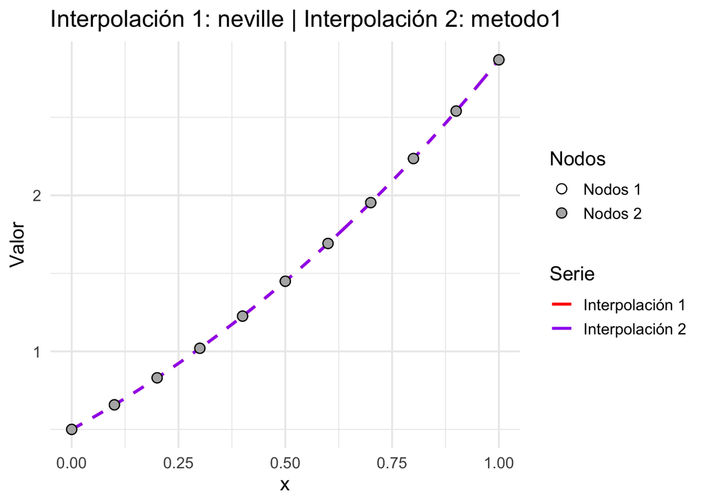

```r
graficar.polinomio(sol[,1], 0, 1, neville, valores1 = sol[,2], nodos2 =  p2.rk4o$t, valores2 = p2.rk4o$w)
```

Problema 3:

**Código**

```r
edo <- function(t, y, parms) {
  dydt <- - ( t * sqrt(1 - y^2) ) / ( y * sqrt(1 - t^2) )
  list(dydt)
}

y0 <- 1
tiempos <- seq(0, 0.999, by = 0.1)

sol <- ode(y = y0,
           times = tiempos,
           func = edo,
           parms = NULL)

sol
```

```
   time 1
1   0.0 1
2   0.1 1
3   0.2 1
4   0.3 1
5   0.4 1
6   0.5 1
7   0.6 1
8   0.7 1
9   0.8 1
10  0.9 1
```

**Código**

```r
graficar.polinomio(sol[,1], 0, 1, neville, valores1 = sol[,2], nodos2 =  p3.euler$t, valores2 = p3.euler$w)
```

[output not shown]

**Código**

```r
graficar.polinomio(sol[,1], 0, 1, neville, valores1 = sol[,2], nodos2 =  p3.euler.pc$t, valores2 = p3.euler.pc$w)
```

[output not shown]

**Código**

```r
graficar.polinomio(sol[,1], 0, 1, neville, valores1 = sol[,2], nodos2 =  p3.rkpm$t, valores2 = p3.rkpm$w)
```

[output not shown]

**Código**

```r
graficar.polinomio(sol[,1], 0, 1, neville, valores1 = sol[,2], nodos2 =  p3.rk4o$t, valores2 = p3.rk4o$w)
```

[output not shown]

4. El mejor método parece ser el de Runge-Kuta de cuarto orden

# Ejercicio 4

**Instrucción del ejercicio 4**

Muestre que el método de **Euler** falla al aproximar la solución

$$u(x) = \left(\frac{2}{3}x\right)^{3/2}$$

para el problema de valor inicial

$$u' = u^{1/3}, \quad u(0) = 0.$$

Explique por qué falla.

**Solución**

La ecuación diferencial es de la forma:

$$u' = u^{1/3}, \quad u(0) = 0.$$

Podemos obtener la solución exacta de la ecuación diferencial. La solución es:

$$u(x) = \left( \frac{2}{3}x \right)^{3/2}.$$

El método de Euler se basa en la siguiente fórmula:

$$u_{i+1} = u_i + h f(x_i, u_i),$$

donde $f(x, u) = u^{1/3}$, y el valor inicial es $u(0) = 0$.

Partimos del valor inicial $u_0 = 0$. En el primer paso, aplicamos la fórmula de Euler:

$$u_1 = u_0 + h f(x_0, u_0) = 0 + h(0^{1/3}) = 0.$$

El valor de $u_1$ no avanza, ya que el valor de la derivada en el primer paso es cero, $f(0, 0) = 0$. Esto hace que el método de Euler falle, ya que no obtiene ningún avance, y por lo tanto no sigue la forma de la solución exacta.

El fallo ocurre debido a la singularidad de la ecuación diferencial en $u = 0$. La función $u^{1/3}$ no es suficientemente suave en $u = 0$, lo que hace que el método de Euler no pueda avanzar adecuadamente. Es un ejemplo clásico de un método numérico que falla cuando se aplica a ecuaciones diferenciales con condiciones iniciales en puntos donde la solución es no diferenciable o tiene un comportamiento singular.

El método de Euler no puede manejar este tipo de singularidades y, por lo tanto, no proporciona una aproximación precisa de la solución.

$\blacksquare$

# Ejercicio 5

**Instrucción del ejercicio 5**

Demuestre que el método de un paso dado por:

$$u_{j+1} = u_j + h f\left(x_j + \frac{h}{2},\, u_j + \frac{h}{2} f(x_j, u_j)\right)$$

es consistente y que, si $f$ es dos veces continuamente diferenciable, entonces tiene **orden dos**  
(este método se conoce como el **método de Euler Modificado**).

Implemente este método en **R** y resuelva las ecuaciones diferenciales del problema 2. Luego grafique.

**Solución**

**Prueba**

Sea $u(x)$ la solución exacta de la EDO $u' = f(x, u)$ con $u(x_j) = u_j$.

Definimos:
$$\phi(x_j, u_j; h) = f\left( x_j + \frac{h}{2}, u_j + \frac{h}{2} f(x_j, u_j) \right).$$

**Consistencia**

El método es consistente si:
$$\lim_{h \to 0} \phi(x_j, u_j; h) = f(x_j, u_j).$$

Como $f$ es continua, y el argumento de $f$ tiende a $(x_j, u_j)$ cuando $h \to 0$, entonces:
$$\lim_{h \to 0} f\left( x_j + \frac{h}{2}, u_j + \frac{h}{2} f(x_j, u_j) \right) = f(x_j, u_j).$$

Por lo tanto, el método es consistente.

**Orden de consistencia 2**

Recordemos que el error de discretización local se define por:
$$\Delta(x_j, u_j; h) = \frac{1}{h}[u(x_j + h) - u(x_j)] - \phi(x_j, u_j; h).$$

Expandiendo $u(x_j + h)$ en serie de Taylor:
$$\begin{align*}
u(x_j + h) &= u(x_j) + h u'(x_j) + \frac{h^2}{2} u''(x_j) + \mathcal{O}(h^3) \\
&= u_j + h f(x_j, u_j) + \frac{h^2}{2} \left( f_x + f_u f \right) + \mathcal{O}(h^3),
\end{align*}$$

donde:
$$u'' = \frac{d}{dx} f(x, u) = f_x + f_u u' = f_x + f_u f.$$

Por otro lado, expandimos $\phi(x_j, u_j; h)$ usando la fórmula de Taylor multivariable:
$$\begin{align*}
\phi(x_j, u_j; h) &= f\left( x_j + \frac{h}{2}, u_j + \frac{h}{2} f(x_j, u_j) \right) \\
&= f(x_j, u_j) + \frac{h}{2} f_x + \frac{h}{2} f_u f + \mathcal{O}(h^2).
\end{align*}$$

Entonces:
$$\begin{align*}
\Delta(x_j, u_j; h) &= \frac{1}{h} \left[ u(x_j + h) - u(x_j) \right] - \phi(x_j, u_j; h) \\
&= f + \frac{h}{2} (f_x + f_u f) - \left[ f + \frac{h}{2} (f_x + f_u f) \right] + \mathcal{O}(h^2) \\
&= \mathcal{O}(h^2).
\end{align*}$$

Por lo tanto, el método tiene **orden de consistencia 2**.

Código

**Código**

```r
# Método de Euler Modificado (RK2)
euler_modificado <- function(f, a, b, y0, N) {
  h <- (b - a) / N
  t <- numeric(N + 1)
  y <- numeric(N + 1)
  t[1] <- a
  y[1] <- y0

  for (i in 1:N) {
    k1 <- f(t[i], y[i])
    k2 <- f(t[i] + h/2, y[i] + (h/2) * k1)
    y[i + 1] <- y[i] + h * k2
    t[i + 1] <- t[i] + h
  }

  data.frame(t = t, y = y)
}
```

Problema 1: $y^\prime = -2ty^2,\quad y(0) = 1$

**Código**

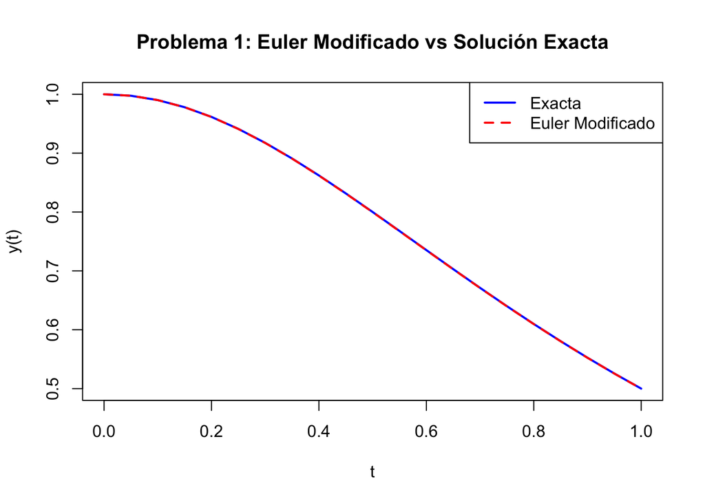

```r
f1 <- function(t, y) {
  -2 * t * y^2
}

# Parámetros
a1 <- 0; b1 <- 1; y01 <- 1; N <- 20
res1 <- euler_modificado(f1, a1, b1, y01, N)

# Solución exacta: y(t) = 1 / (1 + t^2)
y1_exacta <- function(t) {
  1 / (1 + t^2)
}

# Graficar
plot(res1$t, y1_exacta(res1$t), type = "l", col = "blue", lwd = 2,
     main = "Problema 1: Euler Modificado vs Solución Exacta", xlab = "t", ylab = "y(t)")
lines(res1$t, res1$y, col = "red", lty = 2, lwd = 2)
legend("topright", legend = c("Exacta", "Euler Modificado"),
       col = c("blue", "red"), lty = c(1,2), lwd = 2)
```

Problema 2: $y^\prime - y = \cos(t),\quad y(0) = \tfrac{1}{2}$

**Código**

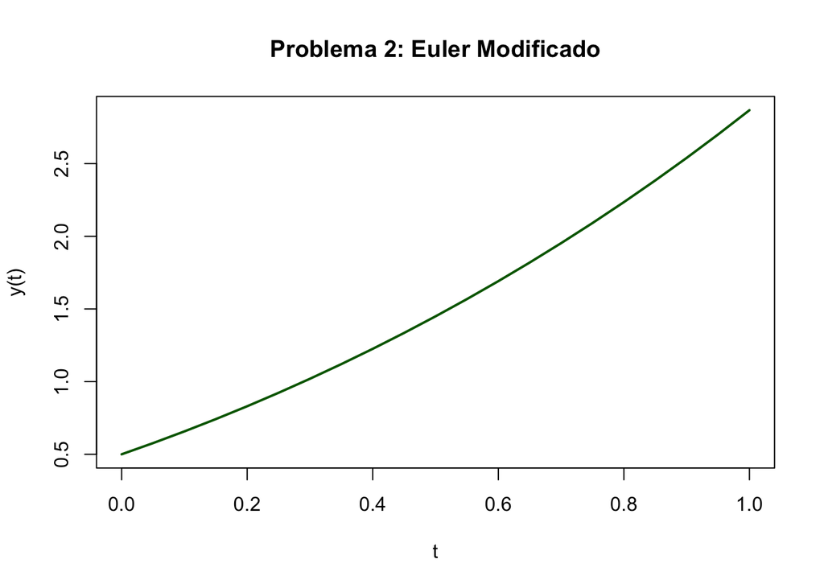

```r
f2 <- function(t, y) {
  cos(t) + y
}

# Parámetros
a2 <- 0; b2 <- 1; y02 <- 0.5
res2 <- euler_modificado(f2, a2, b2, y02, N)

# No hay solución exacta elemental, graficamos solo la aproximada
plot(res2$t, res2$y, type = "l", col = "darkgreen", lwd = 2,
     main = "Problema 2: Euler Modificado", xlab = "t", ylab = "y(t)")
```

Problema 3: Ecuación implícita transformada

**Código**

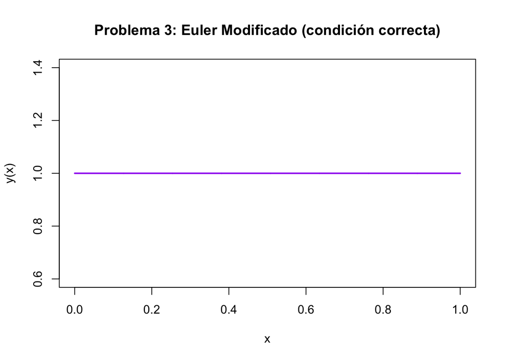

```r
f3 <- function(x, y) {
  - (x * sqrt(1 - y^2)) / (y * sqrt(1 - x^2))
}

a3 <- 0
b3 <- 1
y03 <- 1
N <- 1000

res3 <- euler_modificado(f3, a3, b3, y03, N)

validos <- !is.na(res3$y)
plot(res3$t[validos], res3$y[validos], type = "l", col = "purple", lwd = 2,
     main = "Problema 3: Euler Modificado (condición correcta)",
     xlab = "x", ylab = "y(x)")
```

# Ejercicio 6

**Instrucción del ejercicio 6**

Demuestre que el método de un paso dado por:

$$k_1 = f(x_j, u_j),$$
$$k_2 = f\left(x_j + \frac{h}{3},\, u_j + \frac{h}{3} k_1\right),$$
$$k_3 = f\left(x_j + \frac{2h}{3},\, u_j + \frac{2h}{3} k_2\right),$$
$$u_{j+1} = u_j + \frac{h}{4}(k_1 + 3k_3),$$

es consistente y que, si $f$ es tres veces continuamente diferenciable, entonces tiene **orden tres**  
(este método se conoce como el **método de Tercer Orden de Heun**).

Implemente este método en **R** y resuelva las ecuaciones diferenciales del problema 2. Luego grafique.

**Solución**

Consideramos el problema de valor inicial

$$y'(x) = f(x,y(x)), \qquad y(x_0) = y_0,$$

con $f$ tres veces continuamente diferenciable.

El método de un paso dado es

$$\begin{aligned}
k_1 &= f(x_j,u_j),\\[2pt]
k_2 &= f\!\left(x_j + \tfrac{h}{3},\, u_j + \tfrac{h}{3}k_1\right),\\[2pt]
k_3 &= f\!\left(x_j + \tfrac{2h}{3},\, u_j + \tfrac{2h}{3}k_2\right),\\[2pt]
u_{j+1} &= u_j + \tfrac{h}{4}(k_1 + 3k_3).
\end{aligned}$$

Se puede escribir en la forma general

$$u_{j+1} = u_j + h\,\Phi(x_j,u_j,h),
\quad
\Phi(x_j,u_j,h) = \tfrac14(k_1 + 3k_3).$$

La **definición de consistencia de orden $p$** usada es:

Sea $y$ la solución exacta. Definimos el defecto local

$$\Delta(x,y;h)
= \frac{y(x+h)-y(x)}{h} - \Phi(x,y(x),h).$$

El método es consistente de orden $p$ si existe $k>0$ tal que, para $h$ suficientemente pequeño,

$$|\Delta(x,y;h)| \le k h^p.$$

Demostraremos:

1. $\Delta(x,y;h)\to 0$ cuando $h\to 0$ (consistencia).
2. $|\Delta(x,y;h)| = O(h^3)$, es decir, el método es consistente de orden $3$.

En toda la demostración, cuando escribimos derivadas de $f$ (como $f_x, f_y$, etc.) se entienden evaluadas en el punto $(x,y(x))$ correspondiente.

1. Consistencia

Tomamos el dato exacto en el nodo: $u_j = y_j = y(x_j)$.

Entonces

$$k_1 = f(x_j,y_j).$$

Para $h\to 0$, los argumentos de $f$ en $k_2$ y $k_3$ se acercan también a $(x_j,y_j)$, luego

$$k_2 \to f(x_j,y_j), \qquad
k_3 \to f(x_j,y_j).$$

Por tanto

$$\Phi(x_j,y_j,h)
= \tfrac14(k_1+3k_3)
\longrightarrow \tfrac14(f+3f) = f(x_j,y_j)
\quad (h\to 0).$$

Por otro lado,

$$\frac{y(x_j+h)-y(x_j)}{h} \longrightarrow y'(x_j) = f(x_j,y_j).$$

Entonces

$$\Delta(x_j,y_j;h)
= \frac{y(x_j+h)-y(x_j)}{h} - \Phi(x_j,y_j,h)
\longrightarrow 0.$$

El método es consistente.

2. Orden 3
3. Notación: derivadas a lo largo de la solución

Sea

$$F(x) = f(x,y(x)).$$

Usamos el operador derivada total a lo largo de la solución

$$D = \frac{d}{dx} = \partial_x + f\,\partial_y.$$

Entonces

$$DF = Df(x,y(x)) = f_x + f_y f,$$

$$D^2F = D(DF),
\quad
D^3F = D(D^2F),$$

son combinaciones lineales de derivadas parciales de $f$ hasta orden 3. No necesitamos escribirlas explícitamente: solo que existen y son continuas.

Con esta notación, la expansión de Taylor de la solución es

$$\begin{aligned}
y(x+h)
&= y(x)
+ h F
+ \frac{h^2}{2} DF
+ \frac{h^3}{6} D^2F
+ \frac{h^4}{24} D^3F
+ O(h^5),
\end{aligned}$$

por lo que la pendiente promedio exacta es

$$\frac{y(x+h)-y(x)}{h}
= F + \frac{h}{2}DF + \frac{h^2}{6}D^2F + \frac{h^3}{24}D^3F + O(h^4).$$

Denotaremos esta expresión por $S(h)$.

2. Expansión de las etapas del método

En todo lo siguiente tomamos $u_j = y(x)$.

2.1. Primera etapa

$$k_1 = f(x,y(x)) = F.$$

2.2. Segunda etapa

El método usa

$$k_2 = f\!\left(x + \tfrac{h}{3},\, y(x) + \tfrac{h}{3}k_1\right)
= f\!\left(x + \tfrac{h}{3},\, y(x) + \tfrac{h}{3}F\right).$$

La solución exacta en $x + h/3$ es

$$y\!\left(x+\tfrac{h}{3}\right)
= y(x)
+ \tfrac{h}{3}F
+ \tfrac{h^2}{18}DF
+ \tfrac{h^3}{162}D^2F
+ O(h^4).$$

Por tanto,

$$y(x) + \tfrac{h}{3}F
= y\!\left(x+\tfrac{h}{3}\right)
- \tfrac{h^2}{18}DF
- \tfrac{h^3}{162}D^2F
+ O(h^4),$$

es decir, el argumento en $y$ que usa $k_2$ difiere de la solución exacta en ese punto en una cantidad de orden $h^2$.  
Al aplicar Taylor de $f$ (tres veces diferenciable) en $(x,y)$ hasta orden 3, esto produce

$$k_2
= F
+ \tfrac{h}{3} DF
+ \tfrac{h^2}{18} D^2F
+ \tfrac{h^3}{162} D^3F
+ O(h^4).$$

(esta es exactamente la expansión de $f$ en dos variables con $\Delta x = h/3$, $\Delta y = hF/3$, recogiendo los términos usando $D$).

2.3. Tercera etapa

Ahora

$$k_3 = f\!\left(x + \tfrac{2h}{3},\, y(x) + \tfrac{2h}{3}k_2\right).$$

Primero expandimos el argumento en $y$:

usando la expresión de $k_2$,

$$\frac{2h}{3}k_2
= \frac{2h}{3}F
+ \frac{2h^2}{9}DF
+ \frac{2h^3}{27}D^2F
+ O(h^4).$$

La solución exacta en $x + 2h/3$ es

$$y\!\left(x+\tfrac{2h}{3}\right)
= y(x)
+ \tfrac{2h}{3}F
+ \tfrac{2h^2}{9}DF
+ \tfrac{4h^3}{81}D^2F
+ O(h^4).$$

Por tanto

$$y(x) + \tfrac{2h}{3}k_2
= y\!\left(x+\tfrac{2h}{3}\right)
- \tfrac{2h^3}{81}D^2F
+ O(h^4),$$

esto es, de nuevo, el desfase entre el argumento usado por $k_3$ y la solución exacta en ese punto es de orden $h^3$.

Aplicando Taylor de $f$ hasta orden 3 en $(x,y)$ obtenemos

$$k_3
= F
+ \tfrac{2h}{3} DF
+ \tfrac{2h^2}{9} D^2F
+ \tfrac{4h^3}{81} D^3F
+ O(h^4).$$

(esta es la expansión sistemática: aparecen los coeficientes $2/3$, $2/9$, $4/81$ que se obtienen al sustituir los incrementos anteriores en la fórmula de Taylor en dos variables hasta grado 3).

3. Expansión de la función del método

La función $\Phi$ del método es

$$\Phi(x,y,h) = \tfrac14(k_1 + 3k_3).$$

Sustituimos las expansiones:

1. $k_1 = F$.
2. $k_3 = F + \tfrac{2h}{3}DF + \tfrac{2h^2}{9}D^2F + \tfrac{4h^3}{81}D^3F + O(h^4)$.

Entonces

$$\begin{aligned}
k_1 + 3k_3
&= F + 3\left(
F + \tfrac{2h}{3}DF + \tfrac{2h^2}{9}D^2F + \tfrac{4h^3}{81}D^3F
\right)
+ O(h^4) \\
&= 4F
+ 2h\,DF
+ \tfrac{2h^2}{3}D^2F
+ \tfrac{4h^3}{27}D^3F
+ O(h^4).
\end{aligned}$$

Dividiendo por 4:

$$\Phi(x,y,h)
= F
+ \tfrac{h}{2}DF
+ \tfrac{h^2}{6}D^2F
+ \tfrac{h^3}{27}D^3F
+ O(h^4).$$

4. Defecto local y orden 3

Recordamos la pendiente exacta promedio:

$$S(h)
= F
+ \tfrac{h}{2}DF
+ \tfrac{h^2}{6}D^2F
+ \tfrac{h^3}{24}D^3F
+ O(h^4).$$

El defecto local es

$$\Delta(x,y;h)
= S(h) - \Phi(x,y,h).$$

Sustituyendo:

$$\begin{aligned}
\Delta(x,y;h)
&= \left[
F + \tfrac{h}{2}DF + \tfrac{h^2}{6}D^2F + \tfrac{h^3}{24}D^3F
\right]
-
\left[
F + \tfrac{h}{2}DF + \tfrac{h^2}{6}D^2F + \tfrac{h^3}{27}D^3F
\right]
+ O(h^4) \\
&= \left(\tfrac{1}{24} - \tfrac{1}{27}\right) h^3 D^3F
+ O(h^4) \\
&= \tfrac{1}{216} h^3 D^3F + O(h^4).
\end{aligned}$$

Por lo tanto, el primer término no nulo del defecto local es proporcional a $h^3$.

Como $f$ es $C^3$ en la región considerada, las derivadas contenidas en $D^3F$ son continuas y están acotadas.  
Por ello existe una constante $K$ tal que, para $h$ suficientemente pequeño,

$$|\Delta(x,y;h)| \le K h^3.$$

Esto coincide exactamente con la definición de consistencia de orden $p$ con $p = 3$.

**Codigo en R**

**Código**

```r
tercer.orden.huen <- function(a, b, N, alfa, f){
  h <- (b - a) / N
  t <- a
  w <- alfa
  T <- numeric(N + 1)
  W <- numeric(N + 1)
  T[1] <- t
  W[1] <- w
  for (i in 2:(N+1)) {
    k1 <- f(T[i-1], W[i-1])
    k2 <- f(T[i-1] + h/3, W[i-1] + k1*(h/3))
    k3 <- f(T[i-1] + (2/3)*h, W[i-1] + (2*h/3)*k2)

    W[i] <- W[i-1] + (h/4)*(k1 + 3*k3)
    T[i] <- T[i - 1] + h
  }

  tabla <- data.frame(t = T, w = W)

  return(list(t = T, w = W, tabla = tabla))
}
```

Problema 1: $y^\prime = -2ty^2,\quad y(0) = 1$

**Código**

```r
p1 <- tercer.orden.huen(0, 1, 10, 1, function(x, y) -2*x*y^2)
p1$tabla
```

```
     t         w
1  0.0 1.0000000
2  0.1 0.9900887
3  0.2 0.9615244
4  0.3 0.9174227
5  0.4 0.8620724
6  0.5 0.8000164
7  0.6 0.7353196
8  0.7 0.6711698
9  0.8 0.6097831
10 0.9 0.5525078
11 1.0 0.5000145
```

**Código**

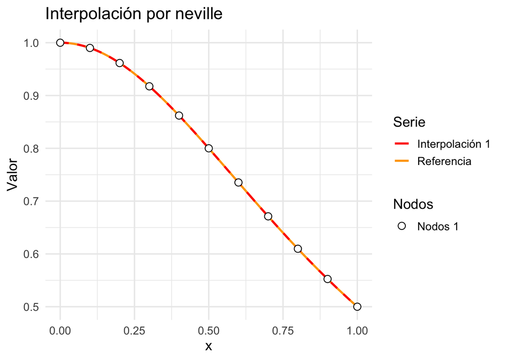

```r
graficar.polinomio(p1$t, 0, 1, neville, valores1 = p1$w, f.referencia = function(t) 1 / (1 + t^2))
```

Problema 2: $y^\prime - y = \cos(t),\quad y(0) = \tfrac{1}{2}$

**Código**

```r
p2 <- tercer.orden.huen(0, 1, 10, 1/2, function(x, y) cos(x) + y)
p1$tabla
```

[output not shown]

**Código**

[figure not shown]

```r
graficar.polinomio(p1$t, 0, 1, neville, valores1 = p1$w, f.referencia = function(t) 1 / (1 + t^2))
```

Problema 3: Ecuación implícita transformada

**Código**

```r
p3 <- tercer.orden.huen(0, 1, 10, 1, function(t, y)- ( t * sqrt(1 - y^2) ) / ( y * sqrt(1 - t^2) ))
p3$tabla
```

```
     t w
1  0.0 1
2  0.1 1
3  0.2 1
4  0.3 1
5  0.4 1
6  0.5 1
7  0.6 1
8  0.7 1
9  0.8 1
10 0.9 1
11 1.0 1
```

**Código**

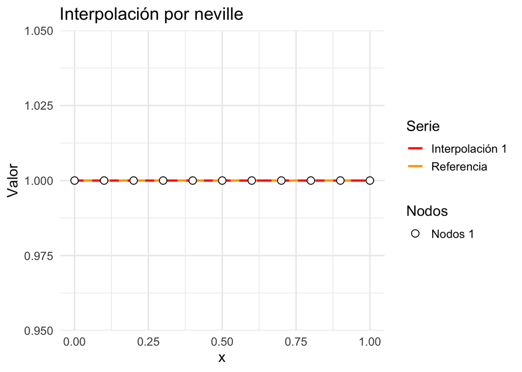

```r
graficar.polinomio(p3$t, 0, 1, neville, valores1 = p3$w, f.referencia = function(x) 1)
```

# Ejercicio 7

**Instrucción del ejercicio 7**

Demuestre que el método de un paso dado por:

$$k_1 = f(x_j, u_j),$$
$$k_2 = f\left(x_j + \frac{h}{2},\, u_j + \frac{h}{2}k_1\right),$$
$$k_3 = f\left(x_j + h,\, u_j - hk_1 + 2hk_2\right),$$
$$u_{j+1} = u_j + \frac{h}{6}(k_1 + 4k_2 + k_3),$$

es consistente y que si $f$ es tres veces continuamente diferenciable entonces tiene **orden tres**  
(este método se conoce como el **método de Tercer Orden de Runge–Kutta**).

Implemente este método en **R** y resuelva las ecuaciones diferenciales del problema 2, luego grafique.

**Solución**

Consideremos el método de un paso definido por:

$$\begin{aligned}
k_1 &= f(x_j, u_j),\\
k_2 &= f\left(x_j + \tfrac{h}{2},\, u_j + \tfrac{h}{2}k_1\right),\\
k_3 &= f\left(x_j + h,\, u_j - hk_1 + 2hk_2\right),\\
u_{j+1} &= u_j + \tfrac{h}{6}(k_1 + 4k_2 + k_3).
\end{aligned}$$

Aplicado al problema de valor inicial

$$y'(x) = f(x, y(x)), \qquad y(x_0) = y_0,$$

suponiendo que ( f ) es tres veces continuamente diferenciable.

- Definición de consistencia

El método es **consistente de orden p** si existe una constante ( K ) tal que para ( h ) suficientemente pequeño se cumple

$$|\Delta(x,y;h)| \le K h^p,$$

donde el defecto local se define como

$$\Delta(x,y;h)
= \frac{y(x+h)-y(x)}{h} - \Phi(x,y(x),h),$$

y

$$\Phi(x,y(x),h) = \tfrac{1}{6}(k_1 + 4k_2 + k_3).$$

Demostraremos que este método es consistente y de orden tres.

1. Pendiente promedio exacta

La expansión de Taylor de la solución exacta ( y(x) ) hasta orden tres es

$$y(x+h) = y(x) + hF + \tfrac{h^2}{2}DF + \tfrac{h^3}{6}D^2F + O(h^4),$$

donde

$$F = f(x,y(x)), \quad D = \partial_x + f(x,y)\partial_y.$$

Dividiendo por ( h ):

$$\frac{y(x+h)-y(x)}{h}
= F + \tfrac{h}{2}DF + \tfrac{h^2}{6}D^2F + O(h^3).$$

Denotaremos esta expresión como la pendiente promedio exacta ( S(h) ).

2. Expansión de las etapas

Etapa 1

$$k_1 = f(x,y(x)) = F.$$

Etapa 2

$$k_2 = f\left(x + \tfrac{h}{2},\, y(x) + \tfrac{h}{2}F\right).$$

La solución exacta en ( x + h/2 ) es

$$y(x + \tfrac{h}{2})
= y(x)
+ \tfrac{h}{2}F
+ \tfrac{h^2}{8}DF
+ \tfrac{h^3}{48}D^2F
+ O(h^4).$$

Por tanto,

$$y(x) + \tfrac{h}{2}F
= y(x + \tfrac{h}{2})
- \tfrac{h^2}{8}DF
- \tfrac{h^3}{48}D^2F
+ O(h^4),$$

lo que implica que el valor de ( y ) que usa el método difiere del valor exacto en una cantidad de orden ( h^2 ).  
Aplicando la expansión de Taylor de ( f ) hasta orden tres:

$$k_2 = F + \tfrac{h}{2}DF + \tfrac{h^2}{8}D^2F + O(h^3).$$

Etapa 3

$$k_3 = f\left(x + h,\, y(x) - hk_1 + 2hk_2\right).$$

Primero, formamos el argumento en ( y ):

$$\begin{aligned}
y(x) - hk_1 + 2hk_2
&= y(x) - hF + 2h\left(F + \tfrac{h}{2}DF + \tfrac{h^2}{8}D^2F\right) + O(h^4)\\
&= y(x) + hF + h^2DF + \tfrac{h^3}{4}D^2F + O(h^4).
\end{aligned}$$

La solución exacta en ( x+h ) es

$$y(x+h) = y(x) + hF + \tfrac{h^2}{2}DF + \tfrac{h^3}{6}D^2F + O(h^4).$$

Por tanto, ambos valores difieren solo en orden ( h^2 ).  
Aplicando nuevamente la expansión de Taylor de ( f ):

$$k_3 = F + hDF + \tfrac{h^2}{2}D^2F + O(h^3).$$

3. Expansión de $\Phi$

$$\Phi(x,y,h)
= \tfrac{1}{6}(k_1 + 4k_2 + k_3).$$

Sustituyendo las expansiones:

$$\begin{aligned}
k_1 + 4k_2 + k_3
&= F + 4\left(F + \tfrac{h}{2}DF + \tfrac{h^2}{8}D^2F\right)
+ \left(F + hDF + \tfrac{h^2}{2}D^2F\right)
+ O(h^3)\\
&= 6F + 3hDF + h^2D^2F + O(h^3).
\end{aligned}$$

Dividiendo entre 6:

$$\Phi(x,y,h)
= F + \tfrac{h}{2}DF + \tfrac{h^2}{6}D^2F + O(h^3).$$

4. Defecto local

La pendiente exacta promedio era

$$S(h) = F + \tfrac{h}{2}DF + \tfrac{h^2}{6}D^2F + O(h^3),$$

de modo que, después de hacer los cálculos, se puede ver que

$$\Delta(x,y;h)
= S(h) - \Phi(x,y,h)
= O(h^3).$$

Por lo tanto, existe una constante $K$ tal que

$$|\Delta(x,y;h)| \le K h^3.$$

**Código**

**Código**

```r
# Método de Euler Modificado (RK2)
runge_kutta_3 <- function(f, a, b, y0, N) {
  h <- (b - a) / N
  t <- numeric(N + 1)
  y <- numeric(N + 1)
  t[1] <- a
  y[1] <- y0

  for (i in 1:N) {
    k1 <- f(t[i], y[i])
    k2 <- f(t[i] + h/2, y[i] + h/2 * k1)
    k3 <- f(t[i] + h, y[i] - h * k1 + 2 * h * k2)
    y[i + 1] <- y[i] + h / 6 * (k1 + 4 * k2 + k3)
    t[i + 1] <- t[i] + h
  }

  data.frame(t = t, y = y)
}
```

Problema 1: $y^\prime = -2ty^2,\quad y(0) = 1$

**Código**

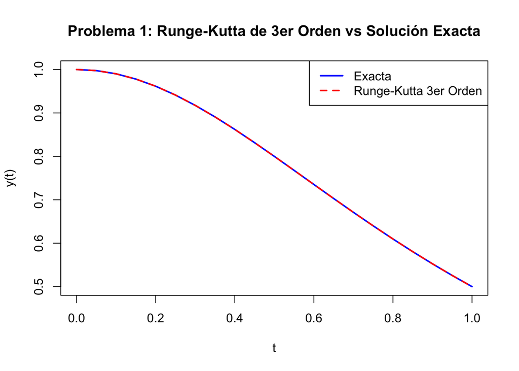

```r
# Función del problema 1
f1 <- function(t, y) {
  -2 * t * y^2
}

# Parámetros
a1 <- 0; b1 <- 1; y01 <- 1; N <- 20
res1 <- runge_kutta_3(f1, a1, b1, y01, N)

# Solución exacta: y(t) = 1 / (1 + t^2)
y1_exacta <- function(t) {
  1 / (1 + t^2)
}

# Graficar
plot(res1$t, y1_exacta(res1$t), type = "l", col = "blue", lwd = 2,
     main = "Problema 1: Runge-Kutta de 3er Orden vs Solución Exacta", xlab = "t", ylab = "y(t)")
lines(res1$t, res1$y, col = "red", lty = 2, lwd = 2)
legend("topright", legend = c("Exacta", "Runge-Kutta 3er Orden"),
       col = c("blue", "red"), lty = c(1,2), lwd = 2)
```

Problema 2: $y^\prime - y = \cos(t),\quad y(0) = \tfrac{1}{2}$

**Código**

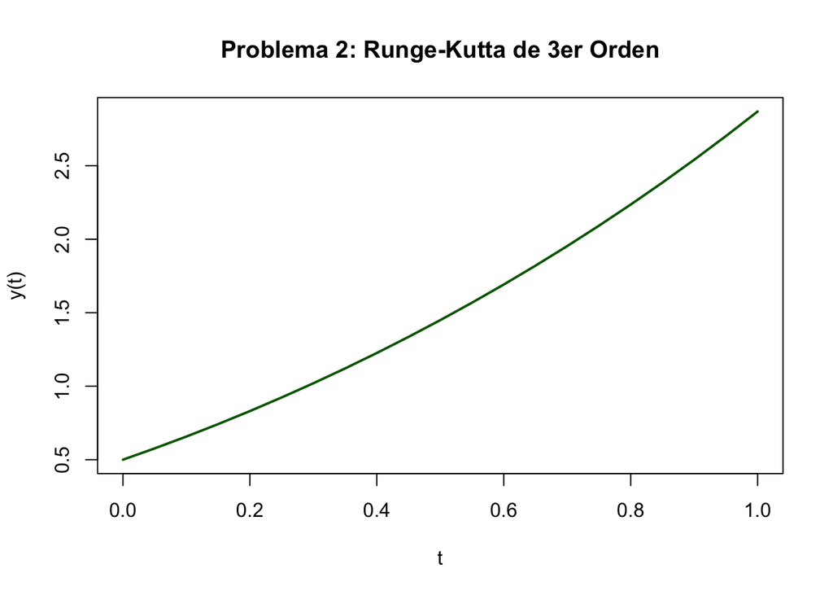

```r
# Función del problema 2
f2 <- function(t, y) {
  cos(t) + y
}

# Parámetros
a2 <- 0; b2 <- 1; y02 <- 0.5
res2 <- runge_kutta_3(f2, a2, b2, y02, N)

# No hay solución exacta elemental, graficamos solo la aproximada
plot(res2$t, res2$y, type = "l", col = "darkgreen", lwd = 2,
     main = "Problema 2: Runge-Kutta de 3er Orden", xlab = "t", ylab = "y(t)")
```

Problema 3: Ecuación implícita transformada

**Código**

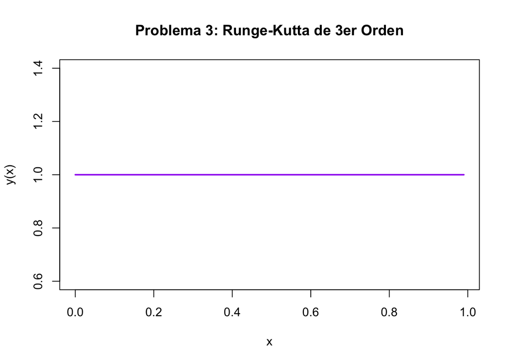

```r
# Función del problema
f3 <- function(x, y) {
  if (is.na(x) || is.na(y) || is.nan(x) || is.nan(y)) return(NA)
  if ((1 - x^2) < 0 || (1 - y^2) < 0 || abs(y) < 1e-8) return(NA)

  - (x * sqrt(1 - y^2)) / (y * sqrt(1 - x^2))
}

# Parámetros
a3 <- 0
b3 <- 1
y03 <- 1
N <- 100

# Resolver con Runge-Kutta de 3er orden
res3 <- runge_kutta_3(f3, a3, b3, y03, N)

# Graficar
validos <- !is.na(res3$y)
plot(res3$t[validos], res3$y[validos], type = "l", col = "purple", lwd = 2,
     main = "Problema 3: Runge-Kutta de 3er Orden",
     xlab = "x", ylab = "y(x)")
```

# Ejercicio 8

**Instrucción del ejercicio 8**

La idea de este ejercicio es introducir la **matriz exponencial** $e^A$ para resolver sistemas de ecuaciones diferenciales.

**Definición:**  
Dada una sucesión $\{C_k\}$ de matrices $m \times n$ cuyos elementos son reales o complejos, se denota por $c_{ij}^k$ la entrada $ij$ de $C_k$.  
Entonces, si todas las $mn$ series

$$\sum\limits_{k=1}^{\infty} c_{ij}^k \quad \text{con } i = 1, 2, \ldots, m; \; j = 1, 2, \ldots, n$$

son convergentes, se dice que la serie de matrices $\sum\limits_{k=1}^{\infty} C_k$ es convergente y su suma es la matriz cuya entrada $ij$ es:

$$\sum\limits_{k=1}^{\infty} c_{ij}^k.$$

1. Pruebe que si $\{C_k\}$ es una sucesión de matrices $m \times n$ tales que  
   $\sum\limits_{k=1}^{\infty} \|C_k\|$ converge, entonces la serie de matrices $\sum\limits_{k=1}^{\infty} C_k$ también es convergente.
2. Pruebe que la serie $\sum\limits_{k=0}^{\infty} \frac{A^k}{k!}$ es convergente.

**Definición**

Dada una matriz $A$, $n \times n$ con elementos reales o complejos, se define la **matriz exponencial** como:

$$e^A = \sum\limits_{k=0}^{\infty} \frac{A^k}{k!}.$$

3. Verifique que si

$$A =
\begin{pmatrix}
1 & 0 & 0 \\
0 & 2 & 0 \\
0 & 0 & 3
\end{pmatrix}$$

entonces

$$e^A =
\begin{pmatrix}
e^t & 0 & 0 \\
0 & e^{2t} & 0 \\
0 & 0 & e^{3t}
\end{pmatrix}.$$

5. Verifique que si

$$A =
\begin{pmatrix}
a & 1 \\
0 & a
\end{pmatrix}$$

entonces

$$e^{tA} =
\begin{pmatrix}
e^{at} & te^{at} \\
0 & e^{at}
\end{pmatrix}.$$

6. Pruebe que para todo $t \in \mathbb{R}$ la función matricial $E(t) = e^{tA}$ satisface la ecuación diferencial matricial:

$$E'(t) = E(t)A = AE(t).$$

7. Dada una matriz $A$, $n \times n$ con elementos reales o complejos, pruebe que para todo $t \in \mathbb{R}$ se cumple:

$$e^{tA} e^{-tA} = I$$

o sea que $e^{tA}$ es no singular y su inversa es $e^{-tA}$.

8. Pruebe que si $A$ y $B$ son dos matrices $n \times n$ con elementos reales o complejos tales que $AB = BA$,  
   entonces:

$$e^{A+B} = e^A e^B.$$

1. Pruebe que, dada una matriz $A$, $n \times n$ con elementos reales o complejos y un vector $B$ de $n$ entradas, entonces el problema de valor inicial:

$$Y'(t) = AY(t)$$
$$Y(0) = B$$

tiene solución única con $t \in \mathbb{R}$ y que esta solución está dada por:

$$Y(t) = e^{tA} B.$$

10. Pruebe que si una matriz cuadrada $A$ es diagonalizable, es decir, que existe una matriz $C$ no singular tal que la matriz $D = C^{-1}AC$ es diagonal, entonces:

$$e^{tA} = C e^{tD} C^{-1}.$$

11. Escriba una función en **R** que reciba una matriz $A$ diagonalizable y retorne $e^{tA}$.  
    Para esto puede usar la función `eigen(...)` de R.
12. Verifique que si

$$A =
\begin{pmatrix}
3 & -1 \\
-2 & 2
\end{pmatrix}$$

entonces

$$e^{tA} = -\frac{1}{3}
\begin{pmatrix}
-e^t - 2e^{4t} & -e^t + e^{4t} \\
-2e^t + 2e^{4t} & -2e^t - e^{4t}
\end{pmatrix}.$$

13. Resuelva el siguiente sistema de ecuaciones diferenciales:

$$\begin{cases}
x_1'(t) = 3x_1(t) - x_2(t) \\
x_2'(t) = -2x_1(t) + 2x_2(t)
\end{cases}$$

sujeto a $x_1(0) = 90$ y $x_2(0) = 150$.

14. Escriba una función en **R** que reciba una matriz $A$ con los coeficientes de un sistema de ecuaciones diferenciales, las condiciones iniciales en una lista de pares, y retorne una lista con las soluciones del sistema de ecuaciones diferenciales.
15. Usando el programa, resuelva el siguiente sistema de ecuaciones diferenciales:

$$\begin{cases}
x_1'(t) = 3x_1(t) - 2x_2(t) \\
x_2'(t) = -2x_1(t) + 3x_2(t) \\
x_3'(t) = 5x_3(t)
\end{cases}$$

sujeto a $x_1(0) = 2$, $x_2(0) = 1$ y $x_3(0) = 3$.

**Solución**

Queremos ver que $\sum_{k=1}^{\infty}c_{ij}^k$ converge

Tome la suma parcial entre dos indices $p$ y $q$ ($p < q$). Note, por desigualdad triangular, que:

$$|\sum_{k=p}^{q}c_{ij}^k|\leq \sum_{k=p}^{q}|c_{ij}^k|$$

Ahora nos apoyamos en el hecho de que cada entrada $|c_{ij}|$ de la matriz está acotada por la norma de la matriz total: $c_{ij} \leq ||C||$ $\forall i, j$

$$\Rightarrow \sum_{k=p}^{q}|c_{ij}^k| \leq \sum_{k=p}^{q}||C_k||$$

Dado que $\sum_{k=p}^{q}||C_k||$ converge, entonces es de Cauchy, por lo cual:

$\forall \epsilon>0 \exists N_0\in \mathbb{N}:N_0<p<q \Rightarrow \sum_{k=p}^{q}||C_k|| < \epsilon$

Juntando todo esto, se concluye que $\sum_{k=1}^{n}c_{ij}^k$ es una sucesion de Cauchy, y dado que “vive” en un espacio completo ($\mathbb{R}$ o $\mathbb{C}$), entonces converge.

Asi pues, dado que hay convergencia en cada entrada de la matriz, podemos ver que $\sum_{k=1}^{\infty}C_k$ converge.

Basta con demostrar que $\sum_{k=0}^{\infty}||\dfrac{A^k}{k!}||$ converge por lo visto en el inciso anterior.

Note que, en el caso de una norma matricial, se tiene que $||\alpha \cdot A|| = |\alpha|\cdot||A||$ y $||AB||\leq||A||\cdot||B||$

$$\Rightarrow ||\dfrac{A^k}{k!}||\leq\dfrac{||A^k||}{k!}$$
$$\Rightarrow \sum_{k = 0}^{\infty}||\dfrac{A^k}{k!}||\leq \sum_{k = 0}^{\infty}\dfrac{||A^k||}{k!} = e^{||A||} < \infty$$
Por lo tanto, $\sum_{k = 0}^{\infty}||\dfrac{A^k}{k!}||$ converge, lo que significa que $\sum_{k = 0}^{\infty}\dfrac{A^k}{k!}$ converge

$$e^{tA}
= \sum_{k=0}^{\infty} \frac{(tA)^k}{k!}
= \sum_{k=0}^{\infty} \frac{1}{k!}
\begin{pmatrix}
1 & 0 & 0\\
0 & 2t & 0\\
0 & 0 & 3t
\end{pmatrix}^{k}
= \sum_{k=0}^{\infty}
\begin{pmatrix}
\frac{1^k}{k!} & 0 & 0\\
0 & \frac{(2t)^k}{k!} & 0\\
0 & 0 & \frac{(3t)^k}{k!}
\end{pmatrix}.$$
Esta ultima igualdad es valida al estar trabajando con una matriz diagonal (de lo contrario no seria tan facil como “solo meter el exponente a cada entrada”)
$$=
\begin{pmatrix}
\displaystyle \sum_{k=0}^{\infty} \frac{1^k}{k!} & 0 & 0\\[8pt]
0 & \displaystyle \sum_{k=0}^{\infty} \frac{(2t)^k}{k!} & 0\\[8pt]
0 & 0 & \displaystyle \sum_{k=0}^{\infty} \frac{(3t)^k}{k!}
\end{pmatrix}
=
\begin{pmatrix}
e^t & 0 & 0\\
0 & e^{2t} & 0\\
0 & 0 & e^{3t}
\end{pmatrix}.$$
e)

**Proposición.** Para todo $n \in \mathbb{N}$,
$$\begin{pmatrix}
a & 1\\
0 & a
\end{pmatrix}^n
=
\begin{pmatrix}
a^n & n\,a^{\,n-1}\\
0 & a^n
\end{pmatrix}.$$

**Demostración**

**Caso base (n = 1(.**
$$\begin{pmatrix}
a & 1\\
0 & a
\end{pmatrix}^1
=
\begin{pmatrix}
a & 1\\
0 & a
\end{pmatrix}
=
\begin{pmatrix}
a^1 & 1\cdot a^0\\
0 & a^1
\end{pmatrix}.$$

**Hipótesis inductiva.** Suponga que para algún $n \ge 1$,
$$\begin{pmatrix}
a & 1\\
0 & a
\end{pmatrix}^n
=
\begin{pmatrix}
a^n & n\,a^{\,n-1}\\
0 & a^n
\end{pmatrix}.$$

**Paso inductivo.**
$$\begin{pmatrix}
a & 1\\
0 & a
\end{pmatrix}^{n+1}
=
\left(
\begin{pmatrix}
a & 1\\
0 & a
\end{pmatrix}^n
\right)
\begin{pmatrix}
a & 1\\
0 & a
\end{pmatrix}
=
\begin{pmatrix}
a^n & n\,a^{\,n-1}\\
0 & a^n
\end{pmatrix}
\begin{pmatrix}
a & 1\\
0 & a
\end{pmatrix}.$$

La multiplicación da:
$$\begin{pmatrix}
a^{n+1} & a^n + n\,a^n\\
0 & a^{n+1}
\end{pmatrix}
=
\begin{pmatrix}
a^{n+1} & (n+1)\,a^{\,n}\\
0 & a^{n+1}
\end{pmatrix}.$$

**Conclusión.** Por el principio de inducción, la fórmula es válida para todo $n \in \mathbb{N}$

Ahora, procedemos con la demostracion solicitada:

Partimos de la definición de la exponencial de matrices:
$$e^{tA}=\sum_{k=0}^{\infty}\frac{(tA)^k}{k!}.$$

Sea
$$A = \begin{pmatrix}
a & 1\\
0 & a
\end{pmatrix}.$$

Entonces
$$(tA)^k
=
t^k
\begin{pmatrix}
a & 1\\
0 & a
\end{pmatrix}^k
=
t^k
\begin{pmatrix}
a^k & k\,a^{k-1}\\
0 & a^k
\end{pmatrix}$$
(donde usamos el resultado probado por inducción).

Sustituimos en la serie:
$$e^{tA}
=
\sum_{k=0}^{\infty}
\frac{t^k}{k!}
\begin{pmatrix}
a^k & k\,a^{k-1}\\
0 & a^k
\end{pmatrix}.$$

Esto equivale a sumar componente a componente:
$$e^{tA}
=
\begin{pmatrix}
\displaystyle \sum_{k=0}^{\infty}\frac{(ta)^k}{k!}
&
\displaystyle \sum_{k=0}^{\infty}\frac{k\,t^k\,a^{k-1}}{k!}
\\[10pt]
0
&
\displaystyle \sum_{k=0}^{\infty}\frac{(ta)^k}{k!}
\end{pmatrix}.$$

Reconocemos series conocidas: - La serie de la diagonal es (e^{ta}). - Para la serie del elemento fuera de la diagonal, usamos:
$$\sum_{k=1}^{\infty}\frac{k\, t^k \, a^{k-1}}{k!}
= t \sum_{k=1}^{\infty}\frac{(ta)^{k-1}}{(k-1)!}
= t e^{ta}.$$

Por tanto,
$$e^{tA}
=
\begin{pmatrix}
e^{ta} & t\, e^{ta}\\[4pt]
0 & e^{ta}
\end{pmatrix}.$$

6. Definimos la función exponencial de matriz:
   $$E(t) = e^{tA} = \sum_{k=0}^{\infty} \frac{t^k A^k}{k!}.$$

Esto es,
$$E(t) = I + tA + \frac{t^2 A^2}{2!} + \frac{t^3 A^3}{3!} + \cdots.$$

Note que la serie asociada a la función exponencial es uniformemente convergente, lo que permite derivar término por término.

Entonces:
$$E'(t) = \sum_{k=0}^{\infty} \frac{d}{dt}\left(\frac{t^k A^k}{k!}\right)
= \sum_{k=1}^{\infty} \frac{k\, t^{k-1} A^k}{k!}.$$

Reescribimos el coeficiente:
$$\frac{k}{k!} = \frac{1}{(k-1)!},$$
por lo que:
$$E'(t) = \sum_{k=1}^{\infty} \frac{t^{k-1} A^k}{(k-1)!}.$$

Cambiamos índice usando (m = k-1):
$$E'(t) = \sum_{m=0}^{\infty} \frac{t^{m} A^{m+1}}{m!}.$$

Factorizamos (A):
$$E'(t) = A \sum_{m=0}^{\infty} \frac{t^{m} A^{m}}{m!}.$$

La serie restante es nuevamente (E(t)), por definición. Por tanto:
$$E'(t) = A\,E(t).$$

Del mismo modo, como (A) conmuta con sus potencias,
$$E'(t) = E(t)\,A.$$

**Conclusión.**
$$E'(t) = A\,E(t) = E(t)\,A.$$

Tomemos
$$F(t) = e^{tA} \, e^{-tA}.$$
Nótese que
$$F(t) = I \quad \text{para todo } t \in \mathbb{R}.$$

Observemos que
$$F'(t) = A e^{tA} e^{-tA} + e^{tA}(-A)e^{-tA}
= A F(t) - F(t) A.$$

En particular, para (t=0):
$$F(0) = e^{0 \cdot A} \, e^{0 \cdot (-A)} = I \cdot I = I.$$

Por lo tanto:
$$F(0)=I.$$

Ahora definamos
$$G(t) = F(t) - I.$$
Entonces
$$G(0)=0.$$

Además, como (I) conmuta con toda matriz, se tiene:
$$F'(t)= A F(t) - F(t) A.$$

Sustituyendo (F(t)=I+G(t)):
$$F'(t)= A(I+G(t)) - (I+G(t))A.$$

Esto se simplifica a:
$$A + A G(t) - A - G(t)A = A G(t) - G(t)A.$$

Por lo tanto:
$$G'(t) = A G(t) - G(t) A,
\quad
G(0)=0.$$

Es decir, (G) satisface una ecuación diferencial matricial homogénea con condición inicial nula.

Notemos que (G(t) = 0) es solución de dicha ecuación diferencial.  
Por el **teorema básico de existencia y unicidad de soluciones de EDO**, se concluye que la solución es única.

Entonces:
$$G(t)=0 \quad \text{para todo } t.$$

En consecuencia:
$$F(t) = I \quad \text{para todo } t.$$

**Demostración**

Asumimos:
$$A,B \in \mathbb{C}^{n\times n}\quad\text{y}\quad AB=BA.$$

Definimos la exponencial por serie:
$$e^{X}=\sum_{k=0}^{\infty}\frac{X^{k}}{k!}.$$

Como A y B conmutan, aplica el binomio matricial:
$$(A+B)^k=\sum_{r=0}^{k}\binom{k}{r}A^{\,r}B^{\,k-r}\quad (k\ge 0).$$

Entonces:
$$\begin{aligned}
e^{A+B}
&=\sum_{k=0}^{\infty}\frac{(A+B)^k}{k!}
=\sum_{k=0}^{\infty}\frac{1}{k!}\sum_{r=0}^{k}\binom{k}{r}A^{\,r}B^{\,k-r} \\
&=\sum_{k=0}^{\infty}\sum_{r=0}^{k}\frac{A^{\,r}}{r!}\,\frac{B^{\,k-r}}{(k-r)!}.
\end{aligned}$$

Cambio de índices p=r y q=k−r (p,q≥0, k=p+q):
$$e^{A+B}
=\sum_{p=0}^{\infty}\sum_{q=0}^{\infty}\frac{A^{\,p}}{p!}\,\frac{B^{\,q}}{q!}.$$

Por convergencia absoluta, reordenamos y factorizamos:
$$e^{A+B}
=\left(\sum_{p=0}^{\infty}\frac{A^{\,p}}{p!}\right)
\left(\sum_{q=0}^{\infty}\frac{B^{\,q}}{q!}\right)
= e^{A}\,e^{B}.$$

Asi pues, acabamos de demostrar que:
$$e^{A+B}=e^{A}e^{B}.$$

Sea
$$Y(t)=e^{tA}B.$$

Calculamos su derivada (aqui nos apoyamos en lo encontrado en el inciso f):
$$Y'(t)=\frac{d}{dt}(e^{tA})B = A\,e^{tA}B = A\,Y(t).$$

Además:
$$Y(0)=e^{0\cdot A}B = I\,B = B.$$
Por lo tanto, $Y(t)=e^{tA}B$ cumple el problema planteado.

Para probar unicidad, supongamos por contradicción que existe otra solución Z(t) tal que:
$$Z'(t)=A\,Z(t),\quad Z(0)=B.$$

Definimos:
$$W(t)=Z(t)-Y(t).$$

Entonces:
$$W'(t)=Z'(t)-Y'(t)=A\,Z(t)-A\,Y(t)=A(Z(t)-Y(t))=A\,W(t).$$

La condición inicial:
$$W(0)=Z(0)-Y(0)=B-B=0.$$

Así, W(t) satisface:
$$W'(t)=A\,W(t),\quad W(0)=0.$$

La única solución de este sistema homogéneo con condición inicial cero es:
$$W(t)=0\quad \text{para todo } t\in\mathbb{R}.$$

Por lo tanto:
$$Z(t)=Y(t)\quad\text{para todo }t.$$

**Conclusión.** La solución es única y está dada por:
$$Y(t)=e^{tA}B.$$
j)

**Demostración**

Usamos la definición por serie:
$$e^{tA}=\sum_{k=0}^{\infty}\frac{t^{k}}{k!}\,A^{k}.$$

Primero probamos por inducción que
$$A^{k}=C\,D^{k}\,C^{-1}\quad \text{para todo } k\ge 1.$$

Caso base k=1:
$$A^{1}=A=C\,D\,C^{-1}.$$

Paso inductivo. Suponga cierto para k, entonces
$$A^{k+1}=A^{k}A=(C\,D^{k}\,C^{-1})(C\,D\,C^{-1})
=C\,D^{k}\,(C^{-1}C)\,D\,C^{-1}=C\,D^{k+1}\,C^{-1}.$$
Con ello queda probado por inducción.

Sustituyendo en la serie:
$$\begin{aligned}
e^{tA}
&=\sum_{k=0}^{\infty}\frac{t^{k}}{k!}\,A^{k}
=\sum_{k=0}^{\infty}\frac{t^{k}}{k!}\,C\,D^{k}\,C^{-1} \\[4pt]
&= C\left(\sum_{k=0}^{\infty}\frac{t^{k}}{k!}\,D^{k}\right)C^{-1}
= C\,e^{tD}\,C^{-1}.
\end{aligned}$$

Como D es diagonal, $e^{tD}$ es la diagonal con entradas $e^{t d_i}$, pero la identidad anterior vale en general por la linealidad de la serie.

**Conclusión.**
$$e^{tA}=C\,e^{tD}\,C^{-1}.$$
k)

**Código**

```r
exp_matriz <- function(A, t) {
  eig <- eigen(A)
  C <- eig$vectors
  D <- diag(exp(t * eig$values))
  C %*% D %*% solve(C)
}

A <- matrix(c(3, -1, -2, 2), nrow = 2, byrow = TRUE)
t <- 1
exp_matriz(A, t)
```

```
          [,1]      [,2]
[1,]  37.30486 -17.29329
[2,] -34.58658  20.01157
```

12. **Paso 1. Valores y vectores propios.**
    $$\chi_A(\lambda)=\det\!\begin{pmatrix}3-\lambda&-1\\-2&2-\lambda\end{pmatrix}
    =(\lambda-1)(\lambda-4).$$
    Por tanto, los autovalores son (1) y (4).

Para ($\lambda=4$):
$$A-4I=\begin{pmatrix}-1&-1\\-2&-2\end{pmatrix}\;\Rightarrow\;
v_1=\begin{pmatrix}1\\-1\end{pmatrix}.$$
Para ($\lambda=1$):
$$A-I=\begin{pmatrix}2&-1\\-2&1\end{pmatrix}\;\Rightarrow\;
v_2=\begin{pmatrix}1\\2\end{pmatrix}.$$

**Paso 2. Diagonalización.**
$$C=\begin{pmatrix}1&1\\-1&2\end{pmatrix},\qquad
D=\begin{pmatrix}4&0\\0&1\end{pmatrix},\qquad
C^{-1}=\frac13\begin{pmatrix}2&-1\\[2pt]1&1\end{pmatrix}.$$

**Paso 3. Exponencial por semejanza.**
$$e^{tA}=C\,e^{tD}\,C^{-1},\qquad
e^{tD}=\begin{pmatrix}e^{4t}&0\\0&e^{t}\end{pmatrix}.$$

**Paso 4. Producto final.**
$$\begin{aligned}
e^{tA}
&=
\begin{pmatrix}1&1\\-1&2\end{pmatrix}
\begin{pmatrix}e^{4t}&0\\0&e^{t}\end{pmatrix}
\frac13\begin{pmatrix}2&-1\\1&1\end{pmatrix}\\[6pt]
&=\frac13
\begin{pmatrix}
2e^{4t}+e^{t} & -e^{4t}+e^{t}\\
-2e^{4t}+2e^{t} & e^{4t}+2e^{t}
\end{pmatrix}.
\end{aligned}$$

Esto es equivalente a
$$e^{tA}
=\,-\frac13
\begin{pmatrix}
-\,e^{t}-2e^{4t} & -\,e^{t}+e^{4t}\\
-\,2e^{t}+2e^{4t} & -\,2e^{t}-e^{4t}
\end{pmatrix},$$
que coincide con lo pedido.

ll)

**Sistema**
$$\begin{cases}
x_1'(t)=3x_1(t)-x_2(t),\\
x_2'(t)=-2x_1(t)+2x_2(t),
\end{cases}
\qquad
x_1(0)=90,\; x_2(0)=150.$$

**Forma matricial**
$$X'(t)=A\,X(t),\qquad
A=\begin{pmatrix}3&-1\\-2&2\end{pmatrix},\quad
X(0)=\begin{pmatrix}90\\150\end{pmatrix}.$$

**Exponencial de A** (del cálculo previo)
$$e^{tA}=\frac{1}{3}
\begin{pmatrix}
2e^{4t}+e^{t} & -e^{4t}+e^{t}\\
-2e^{4t}+2e^{t} & e^{4t}+2e^{t}
\end{pmatrix}.$$

**Solución**
$$X(t)=e^{tA}X(0)
=\frac{1}{3}
\begin{pmatrix}
2e^{4t}+e^{t} & -e^{4t}+e^{t}\\
-2e^{4t}+2e^{t} & e^{4t}+2e^{t}
\end{pmatrix}
\begin{pmatrix}90\\150\end{pmatrix}.$$

**Componentes**
$$\begin{aligned}
x_1(t)&=10e^{4t}+80e^{t},\\
x_2(t)&=-10e^{4t}+160e^{t}.
\end{aligned}$$

**Chequeo inicial**
$$x_1(0)=10+80=90,\qquad x_2(0)=-10+160=150.$$

**Código**

```r
resolver.sistema.diferencial <- function(A, condiciones.iniciales, t.puntos) {
  nombres <- sapply(condiciones.iniciales, function(x) as.character(x[[1]]))
  B <- matrix(as.numeric(sapply(condiciones.iniciales, function(x) x[[2]])), ncol = 1)
  sol.mat <- sapply(t.puntos, function(t) exp_matriz(A, t) %*% B)
  if (is.vector(sol.mat)) sol.mat <- matrix(sol.mat, nrow = nrow(A))
  rownames(sol.mat) <- nombres
  soluciones <- lapply(seq_len(nrow(sol.mat)), function(i) as.numeric(sol.mat[i, ]))
  names(soluciones) <- nombres
  list(tiempos = t.puntos, soluciones = soluciones)
}

A <- matrix(c(3, -1, -2, 2), nrow = 2, byrow = TRUE)
condiciones <- list(list("x1", 90), list("x2", 150))
t.grid <- seq(0, 1, by = 0.1)
res <- resolver.sistema.diferencial(A, condiciones, t.grid)
data.frame(t = res$tiempos, do.call(cbind, res$soluciones))
```

```
     t       x1         x2
1  0.0  90.0000  150.00000
2  0.1 103.3319  161.90910
3  0.2 119.9676  173.16903
4  0.3 141.1899  182.77624
5  0.4 168.8763  189.16163
6  0.5 205.7883  189.90484
7  0.6 256.0013  181.30724
8  0.7 325.5467  157.75397
9  0.8 423.3686  110.76125
10 0.9 562.7506   27.55415
11 1.0 763.4440 -111.05641
```

**Código**

```r
A <- matrix(c(3,-2,0,-2,3,0,0,0,5), 3, 3, byrow = TRUE)
cond <- list(list("x1",2), list("x2",1), list("x3",3))
ts <- seq(0, 1, by = 0.1)
res <- resolver.sistema.diferencial(A, cond, ts)
data.frame(t = res$tiempos, do.call(cbind, res$soluciones))
```

```
     t        x1          x2         x3
1  0.0  2.000000   1.0000000   3.000000
2  0.1  2.482117   0.8333957   4.946164
3  0.2  3.191245   0.4729632   8.154845
4  0.3  4.265633  -0.2160563  13.445067
5  0.4  5.932265  -1.4567910  22.167168
6  0.5  8.564329  -3.6181651  36.547482
7  0.6 12.775947  -7.3095903  60.256611
8  0.7 19.578355 -13.5370969  99.346356
9  0.8 30.637386 -23.9607636 163.794450
10 0.9 48.697970 -41.3191610 270.051394
11 1.0 78.284002 -70.1291568 445.239477
```